Vitamin A and Retinoid Derivatives for Lung Cancer: A

Systematic Review and Meta Analysis

Heidi Fritz<sup>1</sup>, Deborah Kennedy<sup>1,2</sup>, Dean Fergusson<sup>4</sup>, Rochelle Fernandes<sup>1,3</sup>, Steve Doucette<sup>4</sup>, Kieran

Cooley<sup>1,2</sup>, Andrew Seely<sup>5</sup>, Stephen Sagar<sup>6</sup>, Raimond Wong<sup>6</sup>, Dugald Seely<sup>1,4</sup>*

1 Department of Research and Epidemiology, The Canadian College of Naturopathic Medicine, Toronto, Ontario, Canada, 2 Leslie Dan Faculty of Pharmacy, The University

of Toronto, Toronto, Ontario, Canada, 3 Laboratory Medicine and Pathobiology (LMP), The University of Toronto, Toronto, Ontario, Canada, 4 Clinical Epidemiology,

Ottawa Hospital Research Institute, Ottawa, Ontario, Canada, 5 Department of Surgery, Ottawa Hospital Research Institute, Ottawa, Ontario, Canada, 6 Department of

Medicine, Juravinski Cancer Centre, McMaster University, Hamilton, Ontario, Canada

Abstract

Background: Despite reported antiproliferative activity of vitamin A and its common use for cancer, there is no

comprehensive synthesis of its safety and efficacy in lung cancers. To address this issue we conducted a systematic review

of the safety and efficacy of vitamin A for the treatment and prevention of lung cancers.

Methods and Findings: Two independent reviewers searched six electronic databases from inception to July 2009 for

clinical, observational, and preclinical evidence pertaining to the safety and efficacy of vitamin A and related retinoids for

lung cancers. 248 studies were included for full review and analysis. Five RCTs assessed treatment of lung cancers, three

assessed primary prevention, and three looked at secondary prevention of lung cancers. Five surrogate studies, 26 phase I/II,

32 observational, and 67 preclinical studies were also included. 107 studies were included for interactions between vitamin

A and chemo- or radiation- therapy. Although some studies demonstrated benefits, there was insufficient evidence overall

to support the use of vitamin A or related retinoids for the treatment or prevention of lung cancers. Retinyl palmitate

combined with beta carotene increased risk of lung cancer in smokers in the large CARET trial. Pooling of three studies

pertaining to treatment and three studies on secondary prevention revealed no significant effects on response rate, second

primary tumor, recurrence, 5-year survival, and mortality. There was a small improvement in event free survival associated

with vitamin A compared to controls, RR 1.24 (95% CI 1.13–1.35). The synthetic rexinoid bexarotene increased survival

significantly among a subset of patients in two RCTs (p,0.014, ,0.087).

Conclusions: There is a lack of evidence to support the use of naturally occuring retinoids for the treatment and prevention

of lung cancers. The rexinoid bexarotene may hold promise for use among a subset of patients, and deserves further study.

Citation: Fritz H, Kennedy D, Fergusson D, Fernandes R, Doucette S, et al. (2011) Vitamin A and Retinoid Derivatives for Lung Cancer: A Systematic Review and

Meta Analysis. PLoS ONE 6(6): e21107. doi:10.1371/journal.pone.0021107

Editor: John D. Minna, Univesity of Texas Southwestern Medical Center at Dallas, United States of America

Received February 22, 2011; Accepted May 19, 2011; Published June 27, 2011

Copyright: � 2011 Fritz et al. This is an open-access article distributed under the terms of the Creative Commons Attribution License, which permits unrestricted

use, distribution, and reproduction in any medium, provided the original author and source are credited.

Funding: This project was supported by a knowledge synthesis grant from the Canadian Institutes of Health Research (CIHR). Deborah Kennedy is supported by

a career development grant from the SickKids Foundation. No additional sources of funding were accessed. The funders had no role in study design, data

collection and analysis, decision to publish, or preparation of the manuscript.

Competing Interests: The authors have declared that no competing interests exist.

* E-mail: dseely@ccnm.edu

Introduction

Lung cancers account for 12% of cancers globally and are the

most common cancer type second only to non-melanoma skin

cancer [1]. Lung cancers are the leading cause of cancer mortality,

with an estimated 159,390 deaths in 2009 in the United States

alone [1,2]. Because of their prevalence, severity, and lack of

effective treatment, it is crucial to find new interventions for the

treatment and prevention of this disease.

Vitamin A is the generic term for a family of related compounds

consisting of retinol and its derivatives, the retinoids [3].

Historically, natural retinoids have been used in the treatment of

lung cancers since the late 70’s when the first human trials were

conducted [4,5,6,7] on the basis of antiproliferative effects specific

to epithelial tissues and tumors [8,9,10,11]. The development of

synthetic retinoids occurred subsequently in an attempt to retain

vitamin A’s antiproliferative effects specific to epithelial tissue

while avoiding dose limiting side effects such as skin and liver

toxicity [4,12]. A recent survey of lung cancer patients found that

54% used complementary and alternative therapies, with vitamin

combinations being the most common, at 17% [13]. Additionally,

out of ten natural health products (NHPs) assessed during an initial

scoping review of the literature for this project, vitamin A had the

greatest volume and quality of evidence around its use in lung

cancers.

The body obtains vitamin A from two sources: preformed vitamin

A (retinol and retinal in the form of retinyl esters), and provitamin A

carotenoids (beta carotene, alpha carotene, beta cryptoxanthin)

[14,15]. Preformed vitamin A is found in cod liver oil, butter, eggs,

animal products, and fortified grains [14]. Provitamin A carotenoids

are found in highly pigmented vegetables such as carrots, squash,

yams, and green leafy vegetables [14]. Once in the body, retinol is

ultimately converted into retinoic acid and its isoforms, collectively

known as retinoids [14]. Vitamin A is responsible for the maintenance

of epithelial tissues such as skin, mucus membranes, and lung tissue; it

supports immune function; and plays a key role in mediating vision

[16,17].

Provitamin A carotenoids, particularly beta carotene, have also

been studied for the prevention of lung cancers. Beta carotene acts

in part through its conversion to vitamin A in the intestine and

liver, however, it also independently possesses singlet oxygen

quenching activity. It has been estimated that up to 88% of beta

carotene is converted to retinyl esters in the intestinal wall, while

up to 30% enters lymphatic circulation unchanged [18,19,20].

Beta carotene that reaches the liver undergoes further conversion

to retinol, however a small percentage enters the blood unchanged

[18]. The absorption and conversion of beta carotene to retinol is

limited by several factors, including dose administered, with

enzymatic saturation occurring at higher doses; the surrounding

food matrix; the antagonistic effect of other carotenoids and

vitamin A in the diet; and the vitamin A status of the individual

[18,21]. Beta carotene can correct vitamin A deficiency but it does

not achieve the supraphysiological serum retinol levels attained by

direct vitamin A supplementation. As such it does not possess the

toxicity characteristic of high dose vitamin A supplementation;

rather it results in orange discoloration of the skin [19]. At supra-

repletion doses, the physiological activity of beta carotene beyond

that of restoring vitamin A levels is likely due to its independent

redox function or effects on cellular communication [22,23].

Therefore, vitamin A may have a function in lung cancers distinct

from that of beta carotene. For this reason, and since therapeutic

use of vitamin A in lung cancers typically involves induction of

supraphysiological serum levels, we only focused on the use of

preformed vitamin A and retinoids for the purposes of this review.

Retinoid compounds consist of a basic structure of four isoprenoid

units joined in a head-to-tail manner [24]. A large amount of

variability exists between retinoids, and synthetic derivatives, which

differ considerably in structure from the naturally occurring retinoids,

have been developed in the hopes of avoiding some of the toxicity

associated with the latter. Retinoids may be selective toward the two

major retinoid receptors, retinoic acid receptor (RAR) and retinoid X

receptor (RXR), or non selective pan-agonists [25]. First generation,

or naturally occurring/physiological retinoids are derived from

retinyl palmitate, C36H60O2, and include the isomers of retinoic

acid such as 13-cis retinoic acid (13 CRA), 9-cis retinoic acid (9 CRA),

and all-trans retinoic acid (ATRA) [14,25]. Tretinoin (ATRA) and

isotretinoin (13 CRA) are pharmaceutically produced versions of

these. Alternately, novel synthetics that do not exist naturally have

been designed for use in cancer (bexarotene and fenretinide) and

other proliferative conditions (etretinate) [26,27]. The two most

common supplemental forms of vitamin A are retinyl palmitate and

retinyl acetate [14]. Table 1 outlines the classification of major

retinoids and their primary clinical uses [16,28,29,30,31].

Retinoid molecules possess an antiproliferative effect at the cellular

level via growth arrest signaling, promotion of differentiation, and

induction of apoptosis [25]. Most retinoid activities are mediated by

nuclear receptors: the retinoic acid receptor (RAR) and the retinoid X

receptor (RXR), with subtypes a, ß, and c [25]. These receptors

function as ligand-regulated transcription factors that modulate gene

expression patterns [32]. The exact mechanisms by which these

receptors exert their downstream effect are complex and as yet

incompletely elucidated, however they are thought to activate

pathways that converge on G1 cell cycle arrest [28]. Retinoic acid

has also been shown to downregulate markers of proliferation such as

hTERT and cyclins D1 and 3 [33,34], markers of DNA damage such

as 8-oxo dGuo [35], and growth factors such as epidermal growth

factor receptor (EGFR) and vascular endothelial growth factor

(VEGF), potentially inhibiting tumor growth, angiogenesis, and

metastasis [28,36]. Tumor progression has been associated with

decreased RARß expression, as a result it has also been proposed that

retinoic acid inductible RARß may act directly as a tumor suppressor

[25]. Retinoids are also thought to modulate additional targets such

Table 1. Retinoid Classification.

Common name

Generic name (Brand

name if applicable)

Classification

Primary Use

Physiological retinoids

First Generation

All trans retinoic acid

tretinoin

classical* natural or synthetic;

RAR agonist [29,30]

Acute promyelocytic

leukemia (APL) [5]

9 cis retinoic acid

alitretinoin

nonclassical{ natural or synthetic;

RAR + RXR agonist [29,30]

Kaposi’s sarcoma [30]

13 cis retinoinc acid

isotretinoin (Accutane)

classical natural or synthetic;

RAR agonist [25]

Acne vulgaris [5]

Synthetic retinoids

Second Generation

Same as generic name

etretinate (Tegrison) OR acretin

(Soriatane) its metabolite

synthetic, receptor dependent,

aromatic retinoid

Psoriasis [27,31,32]

Third Generation

Same as generic

name

bexarotene (Targretin)

synthetic receptor dependent;

RXR agonist (rexinoid) [25]

Cutaneous T-cell

lymphoma [5,28,33]

4-HPR (N-4 hydroxyphenyl

retinamide)

fenretinide

synthetic RAR agonist and receptor

independent retinoid (atypical{ retinoid) [30]

Breast cancer

chemoprevention [30]

*Classical refers to retinoic acid receptor (RAR) agonism.

{Nonclassical refers to rexinoid receptor (RXR) agonism.

{Atypical refers to receptor independent retinoids.

doi:10.1371/journal.pone.0021107.t001

as reactive oxygen species, mitochondrial permeability, lipoxygenase,

cyclooxygenase-2 (Cox-2), nuclear factor-kB, ubiquitination, tumor

necrosis factor-a, c-Myc, Ap-1, and cell surface death receptors [37].

Preneoplastic and neoplastic diseases successfully treated with

retinoids include oral leukoplakia, cervical dysplasia and xeroderma

pigmentosum (premalignant), and acute promyelocytic leukemia

(APL), a malignant condition characterized by altered signalling

through both the promyelocyte leukemia protein (PML) and

retinoic acid receptor a (RARa) [25,38]. Modest but encouraging

results have been found in the treatment of other cancer types

including: head and neck cancer, cutaneous T-cell lymphoma, and

neuroblastoma [39,40], with increased survival (p,0.01) and

reduced rates of second primary tumors (p = 0.005) demonstrated

in some studies [41,42]. The utilization of retinoids for the

chemoprevention of lung cancers has been controversial, however,

exemplified in the findings of the large CARET trial (Beta Carotene

and Retinol Efficacy Trial) [43].

Given the range of vitamin A utilization and the possibility for

harm in lung cancers, all levels of evidence, clinical and preclinical,

were included in this synthesis of current knowledge pertaining to

the safety and efficacy of vitamin A and its natural and synthetic

derivatives for the treatment or prevention of lung cancers. We

also assessed for potential interactions between Vitamin A and

retinoids with chemotherapy and radiation treatment.

Methods

Search Strategy

We searched the following electronic databases for all levels of

evidence pertaining to vitamin A and lung cancer: Pubmed,

EMBASE, CINAHL, AltHealthWatch, the Cochrane Library,

and the National Library of Science and Technology, from

inception to the end of July 2009. We used a broad based MeSH

and keyword approach combining clinical (lung cancer) and

therapeutic (vitamin A) search terms. Separate searches were

conducted independently by HF and DAK. After initial searches

were completed, the scope of the review was expanded to include

keywords associated with synthetic and naturally occurring

retinoids. This additional search was conducted based on the

premise that retinoids are derivatives of vitamin A that retain a

similar mechanism of action while ostensibly posing less risk of

toxicity and furthermore are used clinically. Table S1 provides

details on the search terms and strategy used to collect the records

for screening from both searches employed.

A third search was conducted in Pubmed and EMBASE from

inception to the end of October 2009 to identify articles pertaining

to vitamin A and interactions with drugs used in lung cancer

treatment and/or radiation therapy, irrespective of cancer type.

Evidence of interactions were from clinical trials, observational

studies, case reports, and preclinical studies where chemotherapy

drugs and/or radiation therapy for lung cancers were assessed.

Study Selection

Screening of studies was initially conducted based on title review.

In the event of uncertainty, abstracts and/or full texts were also

reviewed. Only English language publications were included. For

inclusion, human trials had to assess the efficacy of natural or

synthetic retinoids in lung cancers for the purposes of treatment,

primary or secondary prevention, reduction of side effects and

toxicities associated with chemo- or radiation- therapy, or assess for

potential interactions with these therapies. Uncontrolled human trials

were included, however they were evaluated separately, and in the

absence of a comparator arm, determination of positive or negative

outcome was based on the authors’ interpretation of their findings (i.e.

self assessed). Biomarker studies in humans were included if they

examined endpoints directly related to lung cancer risk or

pathogenesis. All types of lung cancers (SCLC, NSCLC, mesothe-

lioma) were included.

In order to be included, observational studies had to employ an

objective measure of preformed vitamin A status, such as serum,

plasma, or lung tissue retinol levels, and had to examine the risk of

lung cancers either prospectively or be conducted in patients with

lung cancers comparing vitamin A status to patients without cancer.

Due to the high possibility for confounding, studies examining dietary

intake alone were excluded from analysis. Observational studies

examining intake of supplemental vitamin A were also included.

For inclusion, preclinical studies had to be conducted in lung

cancer models and examine either anticancer effects of vitamin A or

related retinoids, or their interaction with conventional chemo- or

radiation- therapy. Preclinical studies were categorized by results as

positive, negative, neutral, or mixed. The term ‘‘positive’’ designates

studies that found significant anticancer effects from at least one of the

retinoids tested in models of lung cancers, alone or additively with

other agents; ‘‘negative’’ designates studies that found significant pro-

carcinogenic effects alone or in combination with other agents; and

‘‘neutral’’ designates studies that found no significant beneficial effect,

nor any evidence of harm. In the absence of reported levels of

significance, the authors’ interpretation was used to guide classifica-

tion. Studies examining surrogate markers were includedz only if the

surrogates related directly to lung cancer risk or pathogenesis.

Data Extraction and Quality Assessment

Data extraction forms were piloted using duplicate review to

assess inter-researcher reliability. Upon completion of data

extraction in duplicate for fifty percent of human level studies,

there were no major inconsistencies, and further duplication of

data extraction was found to be redundant. Extraction sheets were

prepared partly based on the Consolidated Standards of Reporting

Trials

(CONSORT)

statement,

the

Newcastle-Ottawa

scale

(NOS), and the Score for Assessment of Physical Experiments

on Homeopathy (SAPEH) for clinical trials, observational studies,

and preclinical studies, respectively [44,45,46]. We also extracted

data on study design, patient characteristics, exposures or

interventions, and outcomes. Randomized controlled trials were

additionally assigned a quality score based on the Jadad criteria

[47]. Interactions related articles were extracted similarly and

analyzed for information specifically pertaining to interactions.

Statistical Analysis

For randomized controlled trials, outcome data were pooled

using random effects models weighted by the inverse variance in

Comprehensive Meta-analysis Version 2, Biostat, Englewood, NJ,

USA. Results are presented as risk ratios with 95% confidence

intervals. Heterogeneity was assessed using the I<sup>2</sup>statistic.

Results

Search Results

The combined searches identified 7257 records for screening. A

total of 141 studies were included for efficacy analysis. Five RCTs

were included for the treatment of lung cancers, three RCTs

looked at primary prevention, and three RCTs looked at

secondary prevention of lung cancers. Five surrogate studies and

26 phase I/II studies were included. Thirty-two observational and

67 preclinical studies were also included. For the interactions

component, 107 studies were included for full review and analysis.

See Figure 1 for a flowchart of studies included in the review.

Preclinical Evidence

Sixty-seven preclinical studies of retinoids in lung cancer models

were included for analysis. These studies were included in order to

more clearly establish the biological rationale for retinoid use in lung

cancers. Of the 67 studies, 54 showed results in favour of the retinoids

tested, four showed mixed results, seven showed no effect, and two

showed negative effects. Amongst the positive preclinical findings, the

following anticancer effects were identified and synthesized: inhibi-

tion of growth and proliferation (n=33 occurrences), proapoptotic

(n=15), chemopreventive (n = 14), anti-metastatic, anti-angiogenic,

or anti-invasive (n=7), lung cancer specific cytotoxicity (n=3).

Conversely, one study suggested a co-carcinogenic activity for

supplemental retinyl palmitate when combined with 20-methylcho-

lanthrene (20-MCA) [48] and one study showed a potential pro-

angiogenic effect with increased VEGF levels [49]. Refer to Table

S2 for a detailed summary of preclinical evidence.

Biomarker Trials

In humans, retinoids may modulate mediators of proliferation and

some that are associated with lung cancer progression. An

uncontrolled trial in early stage NSCLC patients suggested that

bexarotene may modulate expression of biomarkers such as cyclins

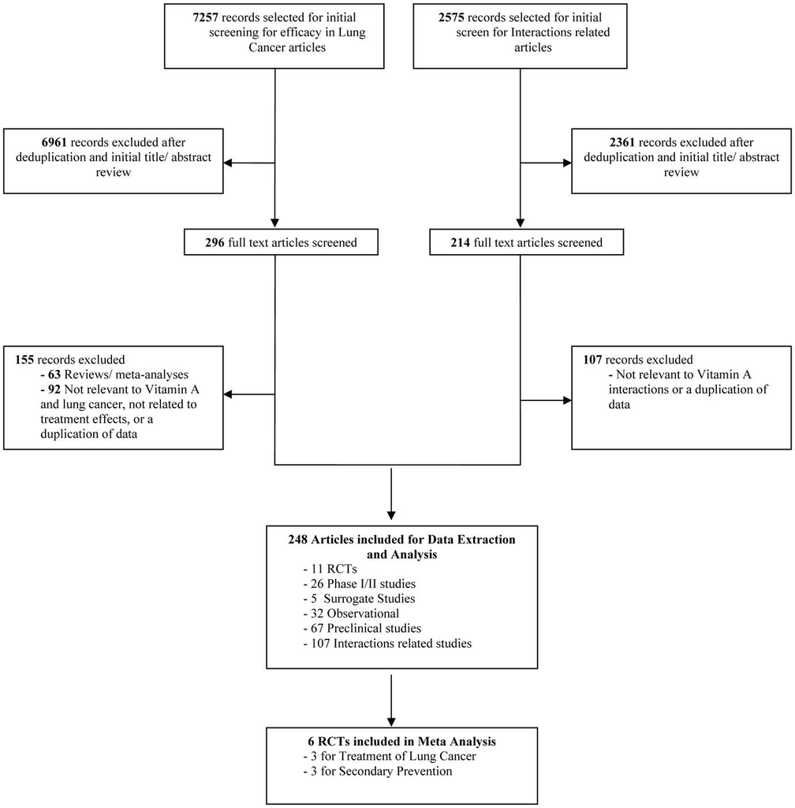

Figure 1. Flowchart of Literature Search and Study Selection.

doi:10.1371/journal.pone.0021107.g001

D1 and 3, and epidermal growth factor receptor (EGFR)

[33,50,51,52]. Of four trials investigating surrogate endpoints in

high risk populations, two showed positive results including

decreased expression of hTERT, a marker of proliferation, in

bronchiolar tissue, and increased RARß expression (decreased

expression of RARß has been associated with lung cancer

development) [34,53]. These trials used fenretinide and 13 CRA,

respectively. Two of the four trials showed no significant effect on

sputum

atypia and bronchial cell metaplasia/dysplasia, also

associated with lung cancer [54,55]. Additionally, one observational

study found no correlation between serum retinol and leukocyte 8-

oxo-dGuo, a marker of DNA damage [35].

Phase I/II Trials

Findings from the 26 included uncontrolled phase I or II trials

suggest limited clinical benefit of vitamin A when used independently

of chemotherapy. Of the 26 studies analyzed, 13 demonstrated

positive results on response rates and/or survival time and 13 showed

retinol palmitate. Of the trials with no significant effect, five used 13

CRA, three used bexarotene, three used ATRA, one used 9 CRA

and one used retinol; there were no major differences in dose ranges

used between the studies with positive and negative findings. These

phase I/II trials were conducted in patients with advanced stages of

lung cancers, and in most cases, retinoids were used in conjunction

with various chemotherapies including: docetaxel and capecitabine,

cisplatin, etoposide, vindesine, mitomycin-C, carboplatin, gemcita-

bine, vinorelbine, 5-fluorouracil, interferon, and interleukin-2.

Conversely, chemotherapy was rarely used in the trials showing no

significant effects. None of the trials demonstrated disease exacerba-

tion when vitamin A or retinoids were employed for treatment.

Controlled Observational Studies

Thirty-two controlled observational studies were included for

analysis.

Seven

of

the

studies

were

prospective,

16

were

retrospective, and 9 were cross-sectional. Of all the observational

studies included, nearly half (n = 15) found an inverse relationship

between serum retinol levels and risk of lung cancers (longitudinal

studies) and/or current diagnoses of lung cancers (cross-sectional

studies). See Tables S4 and S5.

Controlled Clinical Trials

Treatment.

Five

interventional

RCTs

tested

retinoids

(bexarotene and 13 CRA) in either small cell or non-small cell

lung cancers (see Tables S4 and S5) [56,57,58,59,60]. Of these,

one trial comparing 13 CRA + IL-2 versus IL-2 alone demonstrated

improvements in immunological parameters and a decrease in

VEGF. In this trial, a trend towards improvement was also seen in

progression free survival (PFS): 39.3% in the treatment arm versus

30.4% of controls were progression free at 42 months, with a

median PFS of 28.45 months versus 12.35 months, treatment versus

control (HR 0.7356, 95% CI 0.46–1.163, p = 0.185) [56]. Meta

analysis of three trials measuring response rates found no significant

effect

overall,

relative

risk

RR

0.84,

(95%

CI

0.68–1.03,

I<sup>2</sup>= 40.4%). For one study that reported response rates in terms

of complete response, partial response, progressive disease, or

disease stabilization, the response rate was calculated based on the

number of complete and partial responses [60]. See Figure 2.

Two RCTs examining adjuvant bexarotene therapy found

significant survival benefits among a subset of patients who experienced

Grade 3/4 hypertriglyceridemia ($5x upper limit of normal),

compared to the control group: Ramlau reported that these patients

had median survival of 12.3 mo compared to 9.9 mo in the control

group (p=0.087), while Blumenschein reported median survival of

12.4 mo compared to 9.2 mo in similar patients (p=0.014) [57,58].

These responsive patients that represented approximately 30–40% of

the treatment group also had a higher incidence of side effects

including skin rash and hypothyroidism, suggesting that hypertriglyc-

eridemia may be a surrogate of greater systemic biochemical sensitivity

to the effects of bexarotene [57]. Conversely, of the patients receiving

bexarotene and who did not experience Grade 3/4 hypertriglyceri-

demia, a worse treatment response was reported, with significantly

shorter survival than the placebo groups (p,0.0001 for both),

highlighting the need to efficiently identify responders [57,58], Rizvi

also examined bexarotene, however the study was prematurely

terminated due to poor enrollment [59].

Primary Prevention.

Three controlled clinical trials were

found pertaining to vitamin A and primary prevention of lung

cancers [43,61,62]. All of the clinical trials used retinyl palmitate.

Two trials showed no significant effects on lung cancer prevention

overall [61,62], however, one of these did find a significantly

decreased risk of mesothelioma only as separate from SCLC and

NSCLC, RR 0.24 (95% CI 0.07–0.86) [61]. These trials were not

pooled due to heterogeneity in the reporting of results. The large

Carotene and Retinol Efficacy Trial (CARET), however, found

significant increases in lung cancer incidence from combined

treatment

with

retinyl

palmitate

and

beta

carotene

when

administered in high risk populations. Trial results demonstrated

an increase in overall lung cancers, (RR 1.28; 95% CI 1.04-1.57).

Subgroup analysis showed higher risk in asbestos workers (RR

1.40, 95% CI: 0.95–2.07), and current heavy smokers (RR 1.42,

95% CI: 1.07–1.87), while finding a non significant reduction in

risk amongst smokers who had already quit at randomization (RR

0.80, 95% CI: 0.48–1.31) [43]. Relative risk of death from all

causes was 1.18 (95% CI: 1.02–1.37), death from lung cancers

1.46 (95% CI 1.07–2.00), and death from cardiovascular disease

1.26 (95% CI 0.99–1.61) [43]. There was no evidence of increased

risk of other cancer types.

Secondary

Prevention.

Three

controlled

trials

for

the

secondary prevention of lung cancers were included [63,64,65].

Lippman found no significant effects overall, however, lung cancer

recurrence and all cause mortality were significantly increased in

current smokers receiving isotretinoin compared to placebo, HR

3.11 (95% CI 1.00–9.71) and 4.39 (1.11–17.29) respectively [63].

Meta analysis of these three RCTs for secondary prevention

showed no significant effects for vitamin A on second primary

tumor (RR 1.18, 95% CI 0.72–1.94, I<sup>2</sup>= 78.7%), recurrence (RR

0.94, 95% CI 0.74–1.20, I<sup>2</sup>= 47.1%), 5-year survival (RR 1.00,

95% 0.97–1.02, I<sup>2</sup>= 0%), and death (RR 0.94, 95% CI 0.78–1.15,

I<sup>2</sup>= 0%). There was a small but significant improvement in event

free survival associated with vitamin A compared to controls, RR

1.24 (95% CI 1.13–1.35, I<sup>2</sup>= 0%), based on data from two RCTs.

See Figure 2.

Safety and Risks Associated with Use

Adverse Events.

In controlled clinical trials, the most common

side effects observed were grade I-II mucocutaneous symptoms

symptoms including dry skin, rash, conjunctivitis, and chelitis, rever-

sible hypothyroidism, and hyperlipidemia, especially hypertrigly-

ceridemia. In the two controlled studies of bexarotene that reported

incidence, between 63–66% of treated patients experienced hyper-

triglyceridemia compared to 1.3–2.0% of control groups, and between

with antilipid therapy, however in some cases dose reduction was

necessary to prevent patient withdrawal from the study due to toxicity

(up to 18%) [58]. Up to 24% of patients treated with bexarotene

developed

hypothyroidism

manageable

by

thyroid

hormone

replacement therapy [58].

In the Phase I/II trials, the most common side effects observed

were mucocutaneous symptoms (occurring amongst most patients in

some of the trials); hyperlipidemia, in particular hypertriglyceridemia,

ranging from under 44 to 86% in frequency; and elevated liver

function tests (LFTs), in up to 54%. Hypertriglyceridemia and

elevated liver enzymes were most often a grade I/II severity, but

reached grade III/IV in some cases; hypertriglyceridemia and

elevated liver enzymes were reversible upon dose reduction or

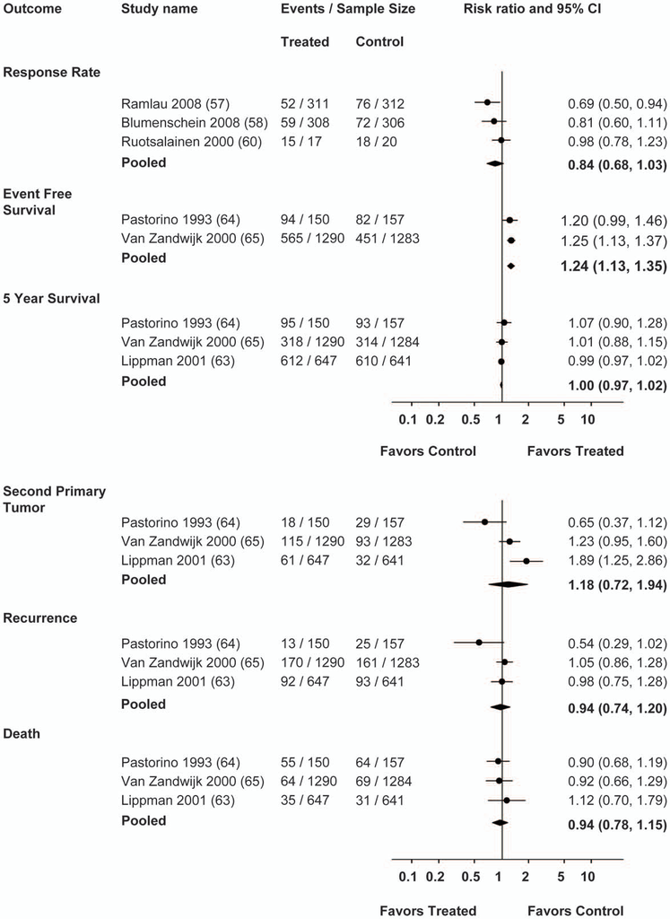

Figure 2. Forest Plots: Pooled Results of RCTs for the Treatment or Prevention of Lung Cancer.

doi:10.1371/journal.pone.0021107.g002

cessation. Less common side effects included mild gastrointestinal

symptoms, headaches, myalgia/arthralgia, and fatigue. Hematolog-

ical toxicities occurred in trials combining retinoids with chemother-

apy, however, these were not common in trials of retinoids alone,

suggesting chemotherapy as the causative agent.

Dose Limiting Toxicities.

In a Phase I trial of ATRA, dose

limiting toxicities (DLTs) of mucocutaneous symptoms, headache,

fatigue, gastrointestinal symptoms, myalgia, and confusion, were

established. These DLTs occurred at 150 mg/m<sup>2</sup>ATRA in

conjunction with cisplatin and etoposide [66]. In a phase I trial of

bexarotene, DLTs included one case of a pain syndrome and one

case of increased creatinine kinase (CK), however the maximum

tolerated dose (MTD) was not reached [67]. Yet another phase I trial

using escalating doses of 200, 300, and 400 mg/m<sup>2</sup>bexarotene did

not reach a MTD as defined at outset, which was the dose level

immediately below the dose level at which 2 patients of a dose level

experienced DLT during their first cycle [68].

Interactions

Table S6 provides an overview of the effects of retinoid/

chemotherapeutic drug combinations in specific cell lines in vitro.

The effects summarized include a combination index (CI) between

the two substances, if reported, and when no CI was reported an

account of either a positive or negative impact on neoplastic cell

growth from the combination is provided in the table.

Emphasis is placed here on the pharmacokinetics changes and

adverse events reported in the literature of the various vitamin A

forms and the chemotherapy drugs used in the treatment of lung

cancer. Case reports were also reviewed however, no relevant

information could be garnered on interactions and these did not

enhance the results, and thus are not reported.

Fenretinide

One phase I study found a reduced Cmax and AUC on day 8 for

fenretinide in combination with cisplatin and paclitaxel, however, in

the absence of serum data, it was not possible to determine whether

the reduction was due to reduced absorption or increased elimination

kinetics [69]. Significant nyctalopia (night blindness), causing

treatment delays, was also reported with the combination of

fenretinide/cisplatin/paclitaxel. Nyctalopia has also been reported

with isotretinion and is thought to develop due to hypovitaminosis A,

which results in a reduction in rhodopsin for the photoreceptors [70].

Bexarotene

Dose limiting toxicities for bexarotene have not been reported

up to 500 mg/m<sup>2</sup>, however, at 600 mg/m<sup>2</sup>and above cases of

hypertriglycemidemia leading to acute pancreatitis have been

reported [71].

All-trans retinoic acid (ATRA)

A larger body of research has been conducted regarding the

pharmacokinetics of ATRA. Absorption of oral ATRA is variable

and highly dependent upon a high fat content in the intestinal

lumen, as ATRA is almost insoluble in an aqueous environment

[72]. Continuous dosing of ATRA has been found to accelerate

elimination of ATRA and an ‘‘on-off’’ the dosing schedule is

suggested to avoid the increased elimination [72]. ATRA has been

found to induce Retinoic Acid Syndrome (RAS) in APL and AML

patients, which can be fatal in some.

13cis – retinoic acid (13CRA)

Waladkhani and Clemens studied the pharmacokinetics of 13

CRA along with interferon a in cancer patients. Their results

demonstrated an increase conversion to the less potent metabolite,

4-oxo 13CRA, in cancer patients versus healthy volunteers

possibly through the up regulation of CYP induced by interferon

a [73]. 13CRA was found to decrease elimination of paclitaxel and

increase the AUC of the metabolite 6-alfa-hydroxytaxol [74].

Discussion

Although vitamin A and related retinoids have been widely used

for the treatment and prevention of lung cancers, our review

suggests that there is a lack of evidence to support this use.

Preliminary evidence including preclinical and observational

studies has shown promising results with respect to lung cancer

pathogenesis and disease risk, respectively, however these effects

have not translated to human interventional settings. Encouraging

preliminary results were found by Pastorino et al. in a setting of

secondary prevention of NSCLC following surgical resection as

well as by de Klerk et al in primary prevention of mesothelioma,

but these have not been replicated by other groups [61,64]. The

CARET trial found adverse effects on overall lung cancer risk

among smokers and asbestos workers, and this seems to be

supported by similar effects among current smokers in the trial by

Lippman [43,63].

There is a lack of RCTs investigating retinoids for lung cancer

treatment; a single trial exists showing clinical benefit when 13

CRA, a naturally occurring retinoid, was combined IL-2, and this

on surrogate immune parameters and levels of VEGF only. Two

RCTs investigating the synthetic rexinoid bexarotene have shown

significant survival benefits in a third of patients manifesting

hypertriglyceridemia as a surrogate of sensitivity, but worse

outcomes in non-responders [57,58]. Further research is required

to elucidate the best genetic predictors or biochemical surrogates

of responsiveness and to confirm these post hoc findings before

bexarotene can be recommended for wider clinical use [75]. At

present these results should not be extrapolated to other retinoids

due to the considerable biochemical differences between them,

however, any future research investigating retinoids, classical or

not, should adopt a similar strategy of identifying a surrogate of

responsiveness among a subgroup of patients.

The reasons for the observed divergence and the lack of

applicability between preclinical findings and the clinical setting

are not clear. It is possible that the appropriate subset of patients

who might benefit from retinyl palmitate or other retinoids has not

been adequately identified by the clinical research to date, as has

been done in the case of bexarotene. Alternately, this divergence

may arise from the inherent differences between preclinical and

clinical research. One theory has been suggested that preclinical

lung cancer models induced by exposure to single carcinogens such

as the nitrosamine 4-(methylnitrosamino)-1-(3-pyridyl)-1-butanone

(NNK) do not accurately mimic the effects of a complex carcinogen

such as cigarette smoke, well accepted to be the most common cause

of lung cancer [76]. This inconsistency has been confirmed, for

instance, in studies of selenium comparing chemoprevention in both

complex- or single- carcinogen lung cancer models, wherein

selenium was able to prevent lung tumors induced by NNK, but

not those caused by exposure to tobacco smoke [76,77].

With respect to observational evidence, it is possible that serum

retinol may be a biomarker of other active anticancer substances

in the diet or of an overall ‘‘healthy’’ dietary pattern. In this case,

interventions with vitamin A alone would be expected to fail. The

biomarker theory is even more applicable to beta carotene which

correlates more directly than serum retinol with intake of fruits

and vegetables and what is considered an overall health-promoting

diet rich in a complex array of chemopreventive substances such as

flavonoids and isothiocyanates [78,79]. This biomarker hypothesis

may explain in part the failure of vitamin A as an interventional

agent, and is especially true insofar as beta carotene contributes to

normal (but not supraphysiological) vitamin A status.

Importantly, CARET, the largest chemoprevention trial to date

of vitamin A and lung cancers, found a significantly increased risk

of lung cancers in the retinol and beta carotene arm [43]. This

trial, consisting of 18,314 current and former smokers and asbestos

workers at high risk of lung cancers, was stopped early due to

interim results showing increased lung cancer risk in the active

arm (retinol and beta carotene), RR 1.28 (1.04–1.57) [43]. When

reported according to the prespecified weighted analysis, this

increased to RR 1.36 (95% CI 1.07 – 1.73) [80]. Follow up results

found that the risk of lung cancers and overall risk of death were

elevated up to six years after the intervention was discontinued,

with greatest impact occurring in women [81]. Adjustment for

baseline beta carotene levels did not modify the elevated risks

associated with active treatment, and the effect retinol and beta

carotene was greatest several years after beginning consumption

[80].

A biomarker study was conducted in a small subgroup of the

CARET population to determine the effect of supplementation on

target tissue levels: bronchoalveolar lavage showed that while tissue

levels of beta carotene increased significantly with supplementation,

retinol levels did not [82]; serum levels increased for both [83]. This

suggests that beta carotene, independent of its provitamin A activity,

may be the culprit responsible for the deleterious effect on lung

cancers observed in this trial. This hypothesis is supported by similar

findings from the large Finnish Alpha Tocopherol Beta Carotene

(ATBC) trial, conducted in 29,133 male smokers for 5 to 8 years.

Investigators found that supplementation of 20 mg beta carotene

without vitamin A increased incidence of lung cancers by 16%

compared to those not receiving beta carotene, RR 1.16 (95% CI

1.02 – 1.33) [84]. Serum retinol levels rose only 6% compared to

placebo in those receiving beta carotene supplementation (p= 0.03)

[85]. This increase in risk is roughly comparable to the 28% effect

seen in CARET.

While the mechanism for the detrimental effects observed have

not been fully elucidated, it is hypothesized that under conditions of

high oxidative stress and exposure to lung irritants such as those

associated with exposure to cigarette smoke and asbestos, certain

antioxidants

may

in

fact

act

as

conditional

pro-oxidants

[22,86,87,88]. According to the conditional pro-oxidant hypothesis,

the activity of an antioxidant depends on its redox potential in

relation to other pro- and anti- oxidants in its microenvironment.

Carotenoids are particularly vulnerable to such oxidation due to

their long chains of conjugated double bonds, and are known to

concentrate in the lungs [89,90,91]. New evidence suggests that

carotene breakdown products (CBPs) produced by high dose

administration under conditions of oxidative stress may act as pro-

oxidants, impairing mitochondrial function and resulting in cellular

damage, thereby predisposing to carcinogenesis [22,91].

Limitations of the chemoprevention studies listed here include

lack of a single-agent intervention arm in CARET, and lack of a

placebo arm in the Western Perth study to distinguish the

potentially differing effects of beta carotene and retinol. CARET

also used a synthetic form of beta carotene. As discussed above,

while beta carotene is a precursor to retinol in the body, it is

nonetheless physiologically distinct in its own right, possessing

redox activity independent of vitamin A [90]. Also, while CBPs

have been shown to impair mitochondrial function, preliminary

evidence suggests that retinol may be an essential response

modifier and cofactor of mitochondrial energy production [92].

The limitations of these chemoprevention trials, however, impede

our ability to draw any definite conclusions about the differential

effects of beta carotene and retinoids on lung cancers in humans.

Notably, a 2008 systematic review and meta- analysis focused

exclusively on beta carotene in relation to cancer risk. Investigators

screened

22,994 records and included six RCTs plus 30

were: 1) the Carotene and Retinol Efficacy Trial (CARET) [43]; 2)

the Alpha Tocopherol Beta Carotene (ATBC) study [94]; 3) the

Physicians’ Health Study (PHS) [95]; 4) the Western Perth,

Australia study [61]; 5) the Women’s Health Study [96]; and 6) the

Linxian General Population trial [62]. The pooled RR for studies

comparing beta carotene supplements to placebo (n = 3) was 1.10

(95% CI 0.89 – 1.36) [93]. In trials conducted in high risk

populations comprised of smokers and asbestos workers (n = 2),

there were significant increases in lung cancer risk associated with

beta carotene supplementation: in the ATBC trial, RR 1.17 (95%

CI 1.02 – 1.34), and in the CARET trial 1.36 (1.07 – 1.72) [93].

In contrast to this interventional data but in agreement with the

biomarker hypothesis, analysis of observational data found that the

pooled RR for lung cancers was decreased in the highest versus the

lowest category of total dietary carotenoid intake for studies

reporting smoking-adjusted risk was 0.79 (95% CI 0.71 – 0.87)

[93]. For intake of beta carotene specifically, there was a non-

significant 8% reduction in smoking-adjusted risk, RR 0.92 (95%

CI 0.83 – 1.01) [93].

This analysis is limited by an exclusive focus on lung cancers

and as such we are unable to draw any conclusions about the

application of retinoids in other cancer types. It is important to

note that there is possible benefits from retinoids in conditions

such as head and neck cancer, mesothelioma, and certain

premalignant conditions. ATRA combined with chemotherapy

has been successful in treating acute promyelocytic leukemia

(APL), inducing remission in what was once a highly lethal

leukemia [25,97]. Reports have shown that classical retinoids

including 13CRA and ATRA may be effective for treatment of

premalignant lesions including leukoplakia, actinic keratosis, and

cervical dysplasia [25,40,98]. In controlled trials on prevention of

head and neck cancer, retinyl palmitate, 13 CRA, and fenretinide

have demonstrated significant response rates [40,99].

With respect to mesothelioma, cancer of the pleural lining of the

lungs, one of the studies reviewed here under primary prevention

found a significantly decreased risk of mesothelioma in the retinol

group, RR 0.24 (0.07-0.86) [61]. A limitation of this study was the

lack of a placebo comparator arm; retinol was instead compared to

beta carotene. It is possible that beta carotene had an overall

adverse effect on disease risk, thereby producing a falsely positive

effect for retinol in comparison, however, this is impossible to

determine.

Strengths of this analysis include a comprehensive and systematic

survey of the literature with a clear focus on lung cancers. All levels of

evidence, human, observational, and preclinical were included to

achieve a broad analysis of anticancer activity of vitamin A/retinoids

in lung cancers, and any possible interactions with chemotherapy

and/or radiation therapy to assess safety alongside efficacy. We are

not aware of another review of vitamin A for lung cancers to date

that has included such an extensive analysis of the available data.

Supporting Information

Table

S1

Search Strings for Vitamin A and Lung

Cancer. *Note: ‘‘Lung neoplasm’’ was the MESH term used

in Pubmed; in other databases, ‘‘Lung cancer’’ was used.

(DOC)

Table S2

Preclinical Evidence. 1,25 vitD 1,25 dihydroxyvi-

taminD; 4-HPR fenretinide; 9CRA 9 cis retinoic acid; 13CRA 13

cis retinoic acid; ATRA all trans retinoic acid; Bex bexarotene;

CDDP cisplatin; d/o depends on; GCB gemcitabine; MDR multi

drug resistance; NGF nerve growth factor; NSCLC non samll cell

lung cancer; PAX paclitaxel; RRMs retinoid relateed molecules;

SCLC small cell lung cancer; VIN vinorelbine; w/w/o with or

without. Footnotes: *Includes effects on tumor growth observed

in animal models of metastasis to the lungs, eg., such as that

induced by intravenous or subcutaneous injection of lung cancer

cells, as well as results from in vitro on markers such as VEGF or

invasive capacity. Thus results from animal models of metastasis

are differentiated from effects on primary tumor growth induced

by adniminstration of carcinogen, and are detailed under this

column, whereas measures of (non-metastatic) primary tumor

growth are categorized under ‘‘Anticancer Effect’’. { + results in

favour of vitamin A; - detrimental results found with vitamin A

use; m mixed effects both positive and negative; n no significant

effect or neutral result; y yes effect demonstrated; – not applicable/

outcome not assessed. { ‘‘Vitamin A’’ stated but precise form not

specified.

(DOC)

Table S3

Uncontrolled Phase I/II Trials for the Treat-

ment of Lung Cancer in Order of the Form of Vitamin A.

5-FU 5-fluorouracil; adv advanced; bw between; CK: creatinine

phosphokinase; CRA cis retinoic acid; d day; DLTs dose limiting

toxicities; EFS event free survival; Gr Grade; IFN interferon;

LFT’s liver function tests; MIU = million IU; mo month; NS =

non significant; NSCLC non small cell lung carcinoma; OS overall

survival; PFS progression free survival; PHA phytohemagglutinin;

pt patients; resp respectively; sign significant; SC subcutaneous;

SCC small cell carcinoma; TC total cholesterol; TG triglyceride;

TTP time to progression; w with; VEGF vascular endothelial

growth factor; wk week; yr year.

(DOC)

Table S4

Methodologies of Controlled Human Studies

for Vitamin A and Lung Cancer. CA cancer; CAD coronary

artery disease; comb combination; f/u follow up; GI gastrointes-

tinal; LTFU loss to follow up; NR not reported; NSCLC non small

cell lung cancer; pop population; PS performance score; SCLC

small cell lung cancer; w with.

(DOC)

Table S5

Outcomes of Controlled Human Studies for

Vitamin A and Lung Cancer. 95% CI 95% confidence

interval; Ad adenocarcinoma; Adj adjusted; AHR adjusted hazard

ratio; AOR adjusted odds ratio; C control group; CR complete

response; DS disease stabilization; DSR disease stabilization rate;

EC epidermoid carcinoma; HR hazard ratio; LC large cell

carcinoma; mo months; NR not reported; NS not significant; OR

odds ratio; PD progressive disease; PR partial response; RR

relative risk; SmC small cell carcinoma; T treatment group.

(DOC)

Table S6

Combination Effect, in vitro, Between Forms

of Vitamin A and Chemotherapy Drugs.

(DOC)

Author Contributions

Conceived and designed the experiments: DS DF KC AS RW SS HF DK.

Performed the experiments: HF RF DK. Analyzed the data: DS DF HF

DK SD. Wrote the paper: HF DK DS.

References

1. Alberg AJ, Brock MV, Samet JM (2005) Epidemiology of lung cancer: looking to

the future. J Clin Oncol 23: 3175–3185.

2. American Cancer Society (2010) Cancer reference information. What are the

key statistics about lung cancer? www.cancer.org. Accessed 9 Debember 2010.

3. Colditz GA, Stampfer MJ, Willett WC (1987) Diet and lung cancer. A review of

the epidemiologic evidence in humans. Arch Intern Med 147: 157–160.

4. Goodman GE, Alberts DS, Meyskens FL (2008) Retinol, vitamins, and cancer

prevention: 25 Years of learning and relearning. J Clin Oncol 26: 5495–5496.

5. Meyskens JFL, Gilmartin E, Chase E (1981) A broad phase II trial of 13-cis-

retinoic acid in advanced cancer. Proc Am Assoc Cancer Res 22: C-151.

6. Micksche M, Cerni C, Kokron O, titscher R, Wrba H (1977) Stimulation of

immune response in lung cancer patients by vitamin A therapy. Oncology 34:

234–238.

7. Wolf G (1996) A history of vitamin A and retinoids. FASEB J 10: 1102–1107.

8. Nettesheim P, Cone MV, Snyder C (1976) The influence of retinyl acetate on

the postinitiation phase of preneoplastic lung nodules in rats. Cancer Res 36:

966–1002.

9. Olsson L, Behnke O, Sorensen HR (1985) Modulatory effects of 5-azacytidine,

phorbol ester, and retinoic acid on the malignant phenotype of human lung

cancer cells. Int J Cancer 35: 189–98.

10. Wilkoff LJ, Dulmadge EA, Chopra DP (1980) Viability of cultured Lewis lung

cell populations exposed to beta retinoic acid. Proc Soc Exp Biol Med 163:

233–236.

11. Nettesheim P, Williams ML (1976) The influence of vitamin A on the

susceptibility of the rat lung to 3-methylcholanthrene. Int J Cancer 17: 351–357.

12. Freemantle SF, Dragnev KH, Dmitrovsky E (2006) The retinoic acid paradox in

cancer chemoprevention. J Natl Cancer Inst 98: 426–427.

13. Micke O, Buntzel J, Kisters K, Schafer U, Micke P, et al. (2010) Complementary

and alternative medicine in lung cancer patients: A neglected phenomenon?

Front Radiat Ther Oncol 42: 198–205.

14. Higdon J (2009) Vitamin A Linus Pauling Institute, Oregon State University,

Available: http://lpi.oregonstate.edu/infocenter/vitamins/vitaminA. Accessed

15 March 2010.

15. Van De, Kulier R, Gulmezoglu AM, Villar J (2002) Vitamin A supplementation

during rpegnancy. Cochrane Database Syst Rev, CD001996.

16. Freemantle SJ, Spinella MJ, Dmitrovsky E (2003) Retinoids in cancer therapy

and chemoprevention: promise meets resistance. Oncogene 22: 7305–7315.

17. O’Neil C, Shevill E, Chang AB (2008) Vitamin A supplementation for cystic

fibrosis. Cochrane Database Syst Rev, CD006751.

18. Tang G (2010) Bioconversion of dietary provitamin A carotenoids to vitamin A

in humans. Am J Clin Nutr 91: 1468S–1473S.

19. Stahl W, Sies H (2005) Bioactivity and protective effects of natural carotenoids.

Biochim Biophys Acta 1740: 101–107.

20. Higdon J, Drake V (2009) Carotenoids: alpha-carotene, beta-carotene, beta-

cryptoxanthin, lycopene, lutein, and zeaxanthin. Linus Pauling Institute, Oregon

State University, Available: http://lpioregonstateedu/infocenter/pytochemicals/

carotenoids. Accessed 15 March 2010.

21. Parker RS (1996) Absorption, metabolism, and transport of carotenoids.

FASEB J 10: 542–551.

22. Black HS 92004) Pro-carcinogenic activity of beta carotene, a putative

photoprotectant. Photochem Photobiol Sci 3: 753–758.

23. Bertram JS, Vine AL (2005) Cancer prevention by retinoids and carotenoids:

independent action on a common target. Biochim Biophys Acta 1740: 170–178.

24. No authors (1982) Nomenclature of retinoids. Recommendations 1981.

Eur J Biochem 129: 1–5.

25. Clarke N, Germain P, Altucci L, Gronemeyer H (2004) Retinoids: potential in

cancer prevention and therapy. Expert Rev Mol Med 6: 1–23.

26. Pilkington T, Brogden RN (1992) Acitretin. A review of its pharmacology and

therpeutic use. Drugs 43: 597–627.

27. Rigas JR, Dragnev KH (2005) Emerging role of rexinoids in non-small cell lung

cancer: focus on bexarotene. Oncologist 10: 22–23.

28. Dragnev KH, Petty WJ, Dmitrovsky E (2003) Retinoid targets in cancer therapy

and chemoprevention. Cancer Biol Ther 2: S150–156.

29. Fritsch PO (1992) Retinoids in psoriasis and disorders of keratinization. J Am

Acad Dermatol 27: S8–14.

30. Bollag W, Holdener EE (1992) Retinoids in cancer prevention and therapy. Ann

Oncol 3: 513–526.

31. Targretin (bexarotene). Eisai Inc. Available: www.Targretin.com Updated 2008.

Accessed 16 March 2010.

32. Pasquali D, Rossi V, Bellastella G, Bellastella A, Sinisi AA (2006) Natural and

synthetic retinoids in prostate cancer. Curr Pharm Des 12: 1923–1929.

33. Dragnev KH, Petty WJ, Shah SJ, Lewis LD, Black Cc, et al. (2007) A proof-of-

principle clinical trial of bexarotene in patients with non-small cell lung cancer.

Clinical Cancer Research 13: 1794–1800.

34. Soria JC, Moon c, Wang L, Hittelman WN, Jang SJ, et al. (2001) Effects of N-(4-

hydroxyphenyl)retinamide on hTERT expression in the bronchial epithelium of

cigarette smokers. J Natl Cancer Inst 93: 1257–1263.

35. Gackowski D, Kowalewski J, Siomek A, Olinski R (2005) Oxidative DNA

damage and antioxidant vitamin level: comparison among lung cancer patients,

healthy smokers and nonsmokers. Int J Cancer 114: 153–156.

36. Fu J, Ding Y, Huang D, Li H, Chen X (2007) The retinoid X receptor-selective

ligand, LGD1069, inhibits tumor-induced angiogenesis via suppression of VEGF

in human non-small cell lung cancer. Cancer lett 248: 153–163.

37. Omenn GS (2007) Chemoprevention of lung cancers: lessons from CARET, the

beta-carotene and retinol efficacy trial, and prospects for the future. Eur J Cancer

Prev 16: 184–191.

38. Hong WK, Endicott J, Itri LM, Doos W, Batsakis JG, et al. (1986) 13-cis-retinoic

acid in the treatment of oral leukoplakia. N Engl J Med 315: 1501–1505.

39. Neely SM, Mehlmauer M, Feinstein DI (1987) The effect of isotretinoin in six

patients with cutaneous T-cell lymphoma. Arch Intern Med 147: 529–531.

40. Smith W, Saba N (2005) Retinoids as chemoprevention for head and neck

cancer: where do we go from here? Crit Rev Oncol Hematol 55: 143–52.

41. Hong WK, Lippman SM, Itri LM, Karp DD, Lee JS, et al. (1990) Prevention of

second primary tumors with isotretinoin in squamous-cell carcinoma of the head

and neck. N Engl J med 323: 795–801.

42. Matthay KK, Reynolds CP, Seeger RC, Shimada H, Adkins ES, et al. (92009)

Long-term results for children with high-risk neuroblastoma treated on a

randomized trial of myeloablative therapy followed by 13-cis-retinoic acid: a

children’s oncology study group. J Clin Oncol 27: 1007–1013.

43. Omenn GS, Goodman GE, Thornquist MD, Balmes J, Cullen MR, et al. (1996)

Effects of a combination of beta carotene and vitamin A on lung cancer and

cardiovascular disease. N Engl J med 334: 1150–1155.

44. Altman DG, Schulz KF, Moher D, Egger M, Davidoff F, et al. (2001) The

revised CONSORT statement for reporting randomized trials: explanation and

elaboration. Ann Intern Med 134: 663–694.

45. Becker-Witt C, Weisshuhn TE, Ludtke R, Willich SN (2003) Quality assessment

of physical research in homeopathy. J Altern Complement Med (: 113–132.

46. Gagnier JJ, Boon H, Rochon P, Moher D, Barnes J, et al. (2006)

Recommendatons of reporting randomized controlled trials of herbal interven-

tions: explanation and elaboration. J Clin Epidemiol 59: 1134–1149.

47. Jadad AR, Moore RA, Carroll D, Jenkinson C, Reynolds DJ, et al. (1996)

Assessing the quality of reports of randomized clinical trials: is blinding

necessary? Control Clin Trials 17: 1–12.

48. Smith WE, Yazdi E, Miller L (1972) Carcinogenesis in pulmonary epithelia in

mice on different levels of vitamin A. Environ Res 5: 152–163.

49. Maeno T, Tanaka T, Sando Y, Suga T, Maeno Y, et al. (2002) Stimulation of

vascular endothelial growth factor gene transcription by all trans retinoic acid

through Sp1 and Sp3 sites in human bronchioloalveolar carcinoma cells.

Am J Respir Cell Mol Biol 26: 246–253.

50. Mitsudomi T, Yatabe Y (2010) Epidermal growth factor receptor in relation to

tumor development: EGFR gene and cancer. FASEB J 277: 301–308.

51. Lonardo F, Rusch V, Langenfeld J, Dmitrovsky E, Klimstra DS (1999)

Overexpression of cyclins D1 and E is frequent in bronchial preneoplasia and

precedes squamous cell carcinoma development. Cancer Res 59: 2470–2476.

52. Rusch V, Klimstra D, Linkov I, Dmitrovsky E (1995) Aberrant expression of p53

or the epidermal growth factor receptor is frequent in early bronchial neoplasia

and coexpression precedes squamous cell carcinoma development. Cancer Res

55: 1365–1372.

53. Ayoub J, Jean-Francois R, Cormier Y, Meyer D, Ying Y, et al. (1999) Placebo-

controlled trial of 13-cis-retinoic acid activity on retinoic acid receptro-beta

expression in a population at high risk: implications for chemoprevention of lung

cancer. J clin Oncol 17: 3546–3552.

54. McLarty JW, Holiday DB, Girard WM, Yanagihara RH, Kummet TD, et al.

(1995) Beta-carotene, vitamin A, and lung cancer chemoprevention: results of an

intermediate endpoint study. Am J Clin Nutr 62: 1431S–1438S.

55. Kurie JM, Lee JS, Khuri FR, Mao L, Morice RC, et al. (2000) N-(4-

hydroxyphenyl)retinamide in the chemoprevention of squamous metaplasia and

dysplasia of the bronchial epithelium. Clinical Cancer Research. pp 2973–2979.

56. Recchia F, Saggio G, Cesta A, Alesse E, Gallo R, et al. (2005) Phase II

randomized study of interleukin-2 with or without 13-cis retinoic acid as

maintenance therapy in patients with advanced cancer responsive to

chemotherapy. Anticancer Res 25: 3149–3158.

57. Ramlau R, Zatloukal P, Jassem J, Schwarzenberger P, Orlov SV, et al. (2008)

Randomized phase III trial comparing bexarotene (L1069-49)/cisplatin/

vinorelbine with cisplatin/vinorelbine in chemotherapy-naı¨ve patients with

advanced or metastatic non-small-cell lung cancer: SPIRIT I. J Clin Oncol 26:

1886–1892.

58. Blumenschein GR, Khuri FR, Von Pawel J, Gatzemeier U, Miller WH, et al.

(2008) Phase III trial comparing carboplatin, paclitaxel, and bexarotene with

carboplatin and paclitaxel in chemotherapy –naı¨ve patients with advanced or

metastatic non-small cell lung cancer: SPIRIT II. J Clin Oncol 26: 1879–1885.

59. Rizvi N, Hawkins MJ, Eisenberg PD, Yocum RC, Reich SD (2001) Placebo-

controlled trial of bexarotene, a retinoid X receptor agonist, as maintenance

therapy for patients treated with chemotherapy for advanced non-small-cell lung

cancer. Clinical Lung Cancer 2: 210–215.

60. Ruotsalainen T, Halme M, Isokangas OP, Pyrho¨nen S, Ma¨ntyla¨ M, et al. (2000)

Interferon-alpha and 13-cis-retinoic acid as maintenance therapy after high-dose

combination chemotherapy with growth factor support for small cell lung cancer

– a feasibility study. Anti-Cancer Drugs 11: 101–108.

61. de Klerk NH, Musk AW, Ambrosini GL, Eccles JL, Hansen J, et al. (1998)

Vitamin A and cancer prevention II: comparison of the effects of retinol and

beta-carotene. Int J Cancer 75: 362–367.

62. Kamangar F, Qiao YL, Yu B, Sun XD, Abnet CC, et al. (2006) Lung cancer

chemoprevention: a randomized, double-blind trial in Linxian, China. Cancer

Epidemiol Biomarkers Prev 15: 1562–1564.

63. Lippman SM, Lee JJ, Karp DD, Vokes EE, Venner SE, et al. (2001)

Randomized phase III intergroup trial of isotretinoin to prevent second primary

tumors in stage I non-small-cell lung cancer. J Natl Cancer Inst 93: 605–617.

64. Pastorino U, Infante M, Maioli M, Chiesa G, Buyse M, et al. (1993) Adjuvant

treatment of stage I lung cancer with high-dose vitamin A. J Clin Oncol 11:

1216–1222.

65. van Zandwijk N, Dalesio O, Pastorino U, de Vries N, van Tinteren H (2000)

EUROSCAN, a randomized trial of vitamin A and N-acetylcysteine in patients

with head and neck cancer or lung cancer. For the European Organization for

Research and Treatment of Cancer Head and Neck and Lung Cancer

Cooperative Groups. J Natl Cancer Inst 92: 977–986.

66. Kalemkerian GP, Jiroutek M, Ettinger DS, Dorighi JA, Johnson DH, et al.

(1998) A phase II study of all-trans-retinoic acid plus cisplatin and etoposide in

patients with extensive stage small cell lung carcinoma: an Eastern Cooperative

Oncology Group Study. Cancer 83: 1102–1108.

67. Dragnev KH, Petty WJ, Shah S, Biddle A, Desai NB, et al. (2005) Bexarotene

and erlotinib for aerodigestive tract cancer. J Clin Oncol 23: 8757–8764.

68. Wildi JD, Baggstrom MQ, Suresh R, Read W, Fracasso PM, et al. (2008) A

phase I study of docetaxel and bexarotene. Chemotherapy 54: 125–130.

69. Guarise A, Faccioli N, Ferrari M, Salvia R, Mucelli RP, et al. (92008) Evaluation

of serial changes of pancreatic branch duct intraductal papillar mucinous

neoplasms by follow-up with magnetic resonance imaging. Cancer Imaging 8:

220–228.

70. Danby FW (2003) Night blindness, vitamin A deficiency, and isotretinoin

psychotoxicity. Dermatol Online J 9: 30.

71. Khuri FR, Rigas JR, Figlin RA, Gralla RJ, Shin DM, et al. (2001) Multi-

institutional phase I/II trial of oral bexarotene in combination with cisplatin and

vinorelbine in previously untreated patients with advanced non-small-cell lung

cancer. J Clin Oncol 19: 2626–2637.

72. Ozpolat B, Lopez-Berestein G, Adamson P, Fu CHJ, Williams AH (2003)

Pharmacokinetics of intravenously administered liposomal all-trans-retinoic acid

(atra) and orally administered atra in healthy volunteers. J Pharm Pharm Sci 6:

292–301.

73. Waladkhani AR, Clemens MR (1997) Differences in the pharmacokinetics of 13-

cis retinoic acid in cancer patients. Int J Cancer 70: 494–495.

74. DiPaola RS, Rafi MM, Vyas V, Toppmeyer D, Rubin E, et al. (1999) Phase I

clinical and pharmacologic study of 13-cis-retinoic acid, interfon alfa, and

paclitaxel in patients with prostate cancer and other advanced malignancies.

J Clin Oncol 17: 2213–2218.

75. Tyagi P, Belani CP, Jain VK (2005) Bexarotene in combination with

chemotherapy fails to prolong survival in patients with advanced non-small-

cell lung cancer: results from the SPIRIT I and II trials. Clin Lung Cancer 7:

17–19.

76. Witschi H (2000) Successful and not so successful chemoprevention of tobacco

smoke-induced lung tumors. Exp Lung Res 26: 743–755.

77. Witschi H, Uyeminami D, Moran D, Espiritu I (2000) Chemoprevention of

tobacco smoke lung carcinogenesis in mice after cessation of smoke exposure.

Carcinogenesis 21: 977–982.

78. Meyskens FL Jr., Szabo E (2005) Diet and cancer: the disconnect between

epidemiology and randomized clinical trials. Cancer Epidemiol Biomarkers Prev

14: 1366–1369.

79. Ray A (2005) Cancer preventive role of selected dietary factors. Indian J Cancer

42: 15–24.

80. Omenn GS, Goodman GE, Thornquist MD, Balmes J, Cullen MR, et al. (1996)

Risk factors for lung cancer and for intervention effects in CARET, the Beta-

Carotene and Retinol Efficacy Trial. J Natl Cancer Inst 88: 1550–1559.

81. Goodman GE, Thornquist MD, Balmes J, Cullen MR, Meyskens FL Jr., et al.

(2004) The Beta-Carotene and Retinol Efficacy Trial: incidence of lung cancer

and cardiovascular disease mortality during 6-year follow-up after stopping beta-

carotene and retinol supplements. J Natl Cancer Inst 96: 1743–1750.

82. Redlich CA, Blaner WS, Van Bennekum AM, Chung JS, Clever SL, et al. (1998)

Effect of supplementation with beta-carotene and vitamin A on lung nutrient

levels. Cancer Epidemiol Biomarkers Prev 7: 211–214.

83. Goodman GE, Omenn GS, Thornquist MD, Lund B, Metch B, et al. (1993)

The Carotene and Retinol Efficacy Trial (CARET) to prevent lung cancer in

high-risk populations: pilot study with cigarette smokers. Cancer Epidemiol

Biomarkers Prev 2: 389–396.

84. Albanes D, Heinonen OP, Taylor PR, Virtamo J, Edwards BK, et al. (1996)

Alpha-Tocopherol and beta-carotene supplements and lung cancer incidence in

the alpha-tocopherol, beta-carotene cancer prevention study: effects of base-line

characteristics and study compliance. J Natl Cancer Inst 88: 1560–1570.

85. Albanes D, Virtamo J, Taylor PR, Rautalahti M, Peitinen P, et al. (1997) Effects

of supplemental beta-carotene, cigarette smoking, and alcohol consumption on

serum carotenoids in the Alpha-Tocopherol, Beta-Carotene Cancer Prevention

Study. Am J Clin Nutr 66: 366–372.

86. van Helden YG, Keijer J, Heil SG, Pico C, Palou A, et al. (2009) Beta-carotene

affects oxidative stress-related DNA damage in lung eipthelial cells and in ferret

lung. Carcinogenesis 30: 2070–2076.

87. Wang XD, Liu C, Bronson RT, Smith DE, Kinsky NI, et al. (1999) Retinoid

signaling and activator protein-1 expression in ferrets given beta-carotene

supplements and exposed to tobacco smoke. J Natl Cancer Inst 91: 60–66.

88. Roehrs M, Valentini J, Bulcao R, Moreira JC, Biesalksi H, et al. (2009) The

plasma retinol levels as pro-oxidant/ oxidant agents in haemodialysis patients.

Nephrol Dial Transplant 24: 2212–2218.

89. Patrick L (2000) Beta-carotene: the controversy continues. Altern Med Rev 5:

530–545.

90. Omenn GS (1998) Chemoprevention of lung cancer: the rise and demise of beta-

carotene. Annu Rev Public Health 19: 73–99.

91. Siems W, Sommerburg O, Schild L, Augustin W, Langhans CD, et al. (2002)

Beta-carotene cleavage products induce oxidative stress in vitro by impairing

mitochondrial respiration. FASEB J 16: 1289–1291.

92. Acin-Perez R, Hoyos B, Zhao F, Vinogradov V, Fischman DA, et al. (2010)

Control of oxidative phosphorylation by vitamin A illuminates a fundamental

role in mitochondrial energy homeostasis. FASEB J 24: 627–636.

93. Gallicchio L, Boyd K, Matanoski G, Tao XG, Chen L, et al. (2008) Carotenoids

and the risk of developing lung cancer: a systematic review. Am J Clin Nutr 88:

372–383.

94. Virtamo J, Pietinen P, Huttunen JK, Korhonen P, Mahila N, et al. (2003)

Incidence of cancer and mortality following alpha-tocopherol and beta-carotene

supplementation: a postintervention follow-up. JAMA 290: 476–485.

95. Cook NR, Le IM, Manson JE, Buring JE, Hennekens CH (2000) Effects of beta-

carotene supplementation on cancer incidence by baseline characteristics in the

Physicians’ Health Study (United States). Cancer Causes Contorl 11: 617–626.

96. Lee IM, Cook NR, Manson JE, Buring JE, Hennekens CH (1999) Beta-carotene

supplementation and incidence of cancer and cardiovascular disease: the

Women’s Health Study. J Natl Cancer Inst 91: 2102–2106.

97. Gregory J, Feusner J (2009) Acute promyelocytic leukemia in childhood. Curr

Oncol Rep 11: 439–445.

98. Lippman SM, Basakis JG, Toth BB, Weber RS, Lee JJ, et al. (1993) Comparison

of low-dose isotretinoin with beta carotene to prevent oral carcinogenesis.

N Engl J Med 328: 15–20.

99. Buntzel J, Kuttner K (1998) Chemoprevention with interferon alfa and 13-cis

retinoic acid in the adjunctive treatment of head and neck cancer. Auris Nasus

Larynx 25: 413–418.